[figure not shown]

# Tensorflow

[figure not shown]

```python
import tensorflow as tf
```

# Low-Level API: Basic Building Blocks

## `tf.Tensor`

```python
tf.constant([1,2,3])
```

```
<tf.Tensor 'Const:0' shape=(3,) dtype=int32>
```

```python
tf.Variable([1,2,3])
```

```
<tf.Variable 'Variable:0' shape=(3,) dtype=int32_ref>
```

```python
tf.placeholder(dtype=tf.float32, shape=[None, 3])
```

```
<tf.Tensor 'Placeholder:0' shape=(?, 3) dtype=float32>
```

## `tf.Operation`

```python
x = tf.placeholder(dtype=tf.float32, shape=[None, 3], name='x')
R = tf.constant([[ 0.0, 1.0, 0.0],
                 [-1.0, 0.0, 0.0],
                 [ 0.0, 0.0, 1.0]], name='R')
y = tf.matmul(x, R)
y
```

```
<tf.Tensor 'MatMul:0' shape=(?, 3) dtype=float32>
```

```python
invariant = tf.equal(tf.norm(y, axis=1), tf.norm(x, axis=1))
invariant
```

```
<tf.Tensor 'Equal:0' shape=(?,) dtype=bool>
```

## `tf.Graph`

The **symbolic calculation** is represented by a `tf.Graph`.

- Allows optimized execution on CPU, GPU, or even distributed
- Graph can be used for automatic differentation

```python
TensorflowGraphToDot(invariant)
```

[figure not shown]

### Automatic Differentiation

```python
partial_derivative = tf.gradients(y, x)
TensorflowGraphToDot(partial_derivative)
```

[figure not shown]

## `tf.Session`

Executes the `tf.Operation`s of a `tf.Graph` on different devices (CPUs, GPUs, Distributed, ...).

**If a tf.Graph is like a .py file, a tf.Session is like the python executable.**

```python
session = tf.InteractiveSession()
session.list_devices()
```

```
[_DeviceAttributes(/job:localhost/replica:0/task:0/device:CPU:0, CPU, 268435456)]
```

```python
session.run(y, feed_dict={x: [[1,2,3], [4,5,6]]})
```

```
array([[-2.,  1.,  3.],
       [-5.,  4.,  6.]], dtype=float32)
```

```python
session.run(invariant, feed_dict={x: np.random.uniform(size=(50, 3))})
```

```
array([ True,  True,  True,  True,  True,  True,  True,  True,  True,
        True,  True,  True,  True,  True,  True,  True,  True,  True,
        True,  True,  True,  True,  True,  True,  True,  True,  True,
        True,  True,  True,  True,  True,  True,  True,  True,  True,
        True,  True,  True,  True,  True,  True,  True,  True,  True,
        True,  True,  True,  True,  True])
```

### Exercise

Modify the above code to calculate a simple percepetron: $$ y = \tanh(W \cdot x + b) $$ Execute the calculation with numpy and with tensorflow.

### Question

Take a look at the partial derivative $\frac{\partial y}{\partial x}$. Why does tensorflow still calculates the $\tanh$ term and not the derivative?

# MNIST

The MNIST database (Modified National Institute of Standards and Technology database) is a **dataset**

- 28x28 images showing handwritten digits
- 55K training, 5K validation and 10K test samples
- multi-class classification task

```python
from tensorflow.examples.tutorials.mnist import input_data
mnist = input_data.read_data_sets("MNIST_data/", one_hot=True)
```

```
Extracting MNIST_data/train-images-idx3-ubyte.gz
Extracting MNIST_data/train-labels-idx1-ubyte.gz
Extracting MNIST_data/t10k-images-idx3-ubyte.gz
Extracting MNIST_data/t10k-labels-idx1-ubyte.gz
```

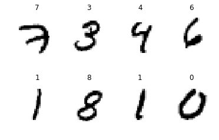

```python
%matplotlib inline
import matplotlib.pyplot as plt
fig, axes = plt.subplots(2, 4)
for i, ax in enumerate(axes.flat):
    ax.set_title(mnist.train.labels[i].argmax())
    ax.imshow(mnist.train.images[i].reshape(28,28), cmap=plt.cm.Greys)
    ax.axis('off')
```

## Linear Model

In machine learning it is best practise to start with the simplest model to establish the overall procedure.

We implement a linear model $f$ with weights $W$: $$ f: R^{784} \rightarrow [0, 1]^{10}$$

$$ f(\vec{x}) = \underbrace{\frac{\exp \vec{l}}{\sum_{i=1}^{10} \exp l_i}}_{\mathrm{softmax}(l)} \quad \quad \textrm{where} \quad \vec{l} = W \cdot \vec{x}$$

```python
x = tf.placeholder(tf.float32, [None, 784])
y = tf.placeholder(tf.float32, [None, 10])
W = tf.Variable(tf.zeros([784, 10]))
logits = tf.matmul(x, W)
probabilities = tf.nn.softmax(logits)
TensorflowGraphToDot(probabilities)
```

[figure not shown]

### Loss-function

For **multi-class classification** one usually wants to minimize the **cross-entropy**.

$$ H(y,p) = - \sum_{i=1}^{10} y_i \log p_i $$

Keep in mind that we always operate on a batch of images (for instance $N = 100$ images per minimization-step). Therefore our loss-function is the average cross-entropy. $$ \mathcal{L} = \frac{1}{N} \sum_{j=1}^{N} H(y_j,p_j) $$

```python
cross_entropy = -tf.reduce_sum(y * tf.log(probabilities + 0.001), axis=[1])
loss_function = tf.reduce_mean(cross_entropy)
```

### Optimization

We use a simple gradient-descent optimizer.

$$ \Delta W = - \eta \frac{\partial \mathcal{L}}{\partial W} \quad \quad \textrm{where} \quad \eta = 0.5 $$

```python
minimize = tf.train.GradientDescentOptimizer(0.5).minimize(loss_function)
```

### Training

Training in tensorflow means just running the **minimize** operation multiple times, here we run 1000 minimization steps. In each step we process a batch of 100 images, and adjusts the weights to minimize the mean cross-entropy of the batch.

### Initializing the Session

Before the training we have to open a new session and initialize all global variables used by tensorflow internally

```python
session = tf.InteractiveSession()
tf.global_variables_initializer().run()
```

### The main training loop

```python
for i in range(1000):
    batch_xs, batch_ys = mnist.train.next_batch(100)
    session.run(minimize, feed_dict={x: batch_xs, y: batch_ys})
```

### Direct Evaluation

Finally we evaluate the linear model. We are interested in the **accuracy** of our model.

```python
correct_prediction = tf.equal(tf.argmax(probabilities, 1), tf.argmax(y, 1))
accuracy = tf.reduce_mean(tf.cast(correct_prediction, tf.float32))
print("Train", session.run(accuracy, feed_dict={x: mnist.train.images, y: mnist.train.labels}))
print("Test ", session.run(accuracy, feed_dict={x: mnist.test.images, y: mnist.test.labels}))
```

```
Train 0.9160909
Test  0.9186
```

### Exercise

Add a bias $\vec{b}$ to the linear model $$ f(\vec{x}) = \underbrace{\frac{\exp \vec{l}}{\sum_{i=1}^{10} \exp l_i}}_{\mathrm{softmax}(l)} \quad \quad \textrm{where} \quad \vec{l} = W \cdot \vec{x} + \vec{b}$$

### Question

What is the purpose of the bias?

# Neural Network in Tensorflow

- Automatic Differentiationen $\rightarrow$ you only implement the forward pass
- Graph is automatically compiled for CPU, GPU, TPU, ... $\rightarrow$ you don't have to write C++, CUDA, ...
- Predefined functions for neural network building blocks $\rightarrow$ you don't have to implement convolution yourself

**Let us take a look at those predefined functions**

## `tf.layers`

The `tf.layers` package contains pre-defined layers commonly used in neural networks:

- convolution layers: `tf.layers.conv2d`
- pooling layers: `tf.layers.max_pooling2d`
- dense (or fully-connected) layers: `tf.layers.dense`

https://www.tensorflow.org/api_docs/python/tf/layers

Using those layers we can easily build a more complex neural network without having to define the weight variables ourselves (like we did in the low-level exercise).

```python
tf.reset_default_graph()
x = tf.placeholder(tf.float32, [None, 784])
image = tf.reshape(x, [-1, 28, 28, 1])
conv = tf.layers.conv2d(image, filters=32, kernel_size=[5, 5], padding="same", activation=tf.nn.relu)
pool = tf.layers.max_pooling2d(conv, pool_size=[4, 4], strides=4)
flat = tf.layers.flatten(pool)
logits = tf.layers.dense(flat, units=10)
TensorflowGraphToDot(logits)
```

[figure not shown]

### Initalization and Regularization

The layers provided by `tf.layers` have a common interface to define initalization and regularization. Most layers have at least the following parameters:

- `activation`, the activation function used by this layer e.g. `tf.nn.relu`
- `kernel_initializer`, the initalisation function used to intialize the weights of the layer
- `kernel_regularizer`, the regularizer used to regularize the weights of the layer e.g. $L_2$ or $L_1$
- `kernel_constraint`, a projection function to enforce certaint constraints on the weights

We won't go into further detail here. But we will use initialization and regularization in the high-level exercise using `tf.keras` later.

## `tf.losses`

The `tf.losses` package contains pre-defined loss-functions commonly used in neural networks. In contrast to the low-level API, the loss is automatically averaged over the current batch.

https://www.tensorflow.org/api_docs/python/tf/losses

```python
y = tf.placeholder(tf.float32, [None, 10])
loss_function = tf.losses.softmax_cross_entropy(y, logits=logits)
minimize = tf.train.GradientDescentOptimizer(0.5).minimize(loss_function)
```

[output not shown]

## `tf.summary`

During the training you can sample interesting quantities. Here we define two summary objects:

- a scalar summary (`tf.summary.scalar`), which records the accuracy during the training
- a histogram summary (`tf.summary.histogram`), which records the distribution of the maximum probability of each sample (a measure on "how confident" our network is in its decision)

```python
correct_prediction = tf.equal(tf.argmax(logits, 1), tf.argmax(y, 1))
accuracy = tf.reduce_mean(tf.cast(correct_prediction, tf.float32))
tf.summary.scalar('summary/accuracy', accuracy)
tf.summary.histogram('summary/max_probability', tf.reduce_max(tf.nn.softmax(logits), axis=1))
summary = tf.summary.merge_all()

train_writer = tf.summary.FileWriter('train_log')
train_writer.add_graph(tf.get_default_graph())
test_writer = tf.summary.FileWriter('test_log')
```

```python
session = tf.InteractiveSession()
tf.global_variables_initializer().run()
for i in range(100):
    batch_xs, batch_ys = mnist.train.next_batch(128)
    session.run(minimize, feed_dict={x: batch_xs, y: batch_ys})

    if i % 10 == 0:
        train_summary = session.run(summary, feed_dict={x: mnist.train.images[:1000], y: mnist.train.labels[:1000]})
        train_writer.add_summary(train_summary, i)
        test_summary = session.run(summary, feed_dict={x: mnist.test.images[:1000], y: mnist.test.labels[:1000]})
        test_writer.add_summary(test_summary, i)
```

```python
print("Train", session.run(accuracy, feed_dict={x: mnist.train.images[:1000], y: mnist.train.labels[:1000]}))
print("Test ", session.run(accuracy, feed_dict={x: mnist.test.images, y: mnist.test.labels}))
```

```
Train 0.958
Test  0.9526
```

## `Tensorboard`

- browser-based application
- visualizes the `tf.Summary` objects sampled during the training
- inspect, monitor and visualize the learning process of a neural network

### Exercise

You can now start tensorboard and inspect your training by executing the following command in `bash`

```
 tensorboard --logdir="."
```

Afterwards open your browser at: http://localhost:6006

### Exercise

In addition to the current summaries: visualize the loss function (scalar) and the distribution of the weights (histogram) in tensorboard.

# High Level Interface - Estimators

Tensorflow is not as easy to use as:

- sklearn
- keras
- ...

The High-Level Tensorflow API was recently introduced to simplify using tensorflow.

It provides an sklearn-like estimator interface, which encapsulates the following actions:

- training
- evaluation
- prediction
- export for serving

It tries to hide tensoflow-details:

- no need to open a session
- no explicit training loop

## Estimator-Interface vs. Keras

Clearly the estimator interface is aimed to be an alternative to Keras, which is the high-level interface most people use.

**Personal Opinion**: The estimator interface is still very confusing, hence we will look into **Keras** for the second part of this workshop!